# main_notebook

The following slides show the analysis of the KPIs. First the number of installs that we get per network and also the number install per network over time. Network 60 has the highest number of installs followed by network 26. The highest number of installs are January and August where we have peaks.

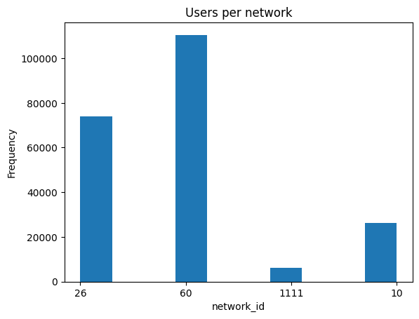

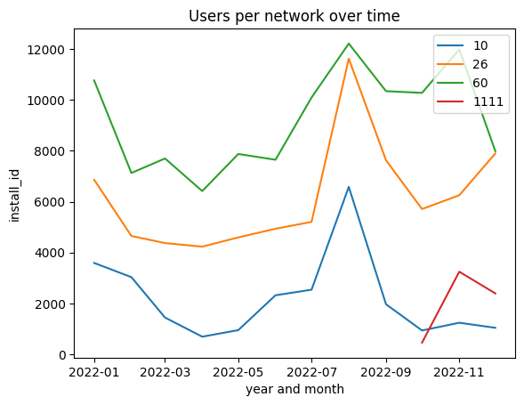

The next analysis is of the user acquisition cost per network. This is based on the number of installs per network and the total amount spent on adverts. The charts below show the average cost of acquisition. The cost on network 10 is $0.96, higher than all the other networks despite coming 3rd when it comes to the number of installations. Network 60 with the most installations costs $0.90 per user and finally 16 and 1111 cost nothing. Based on the time series and the number of installs over time, when the acquisition cost decreased the number of installs also decreased.

```
  network_id  user_acquisition_cost_usd
0         10                   0.959958
1         26                   0.000000
2         60                   0.901864
3       1111                   0.000000
```

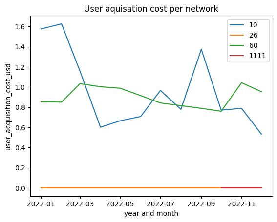

The pie chart below shows the distribution of the average revenue per acquisition per network. Network 60 has the highest revenue, $5.08 which is 35% of the revenue. This is followed by network 10, it accounts for 29% of the revenue as $4.22. This is a positive finding given that it has the highest acquisition cost. Network 26 has a revenue of $3.50 per acquisition that costs $0. Finally, network 1111 has a revenue of $1.58 at $0 acquisition cost. This is also just over 2 months. Comparing the time series, the cost of acquisition seem to have no effect on the revenue.

```
   network_id  revenue_per_install_usd
0          10                 4.215547
1          26                 3.498905
2          60                 5.086835
3        1111                 1.583400
```

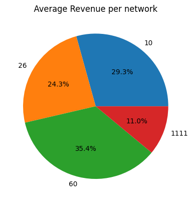

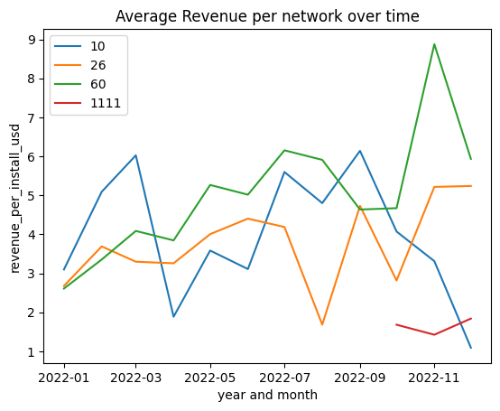

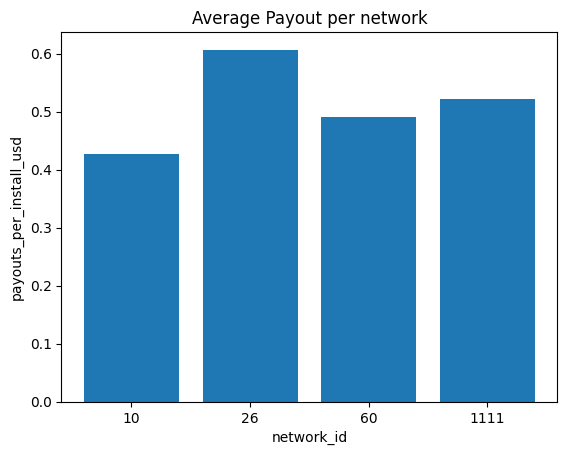

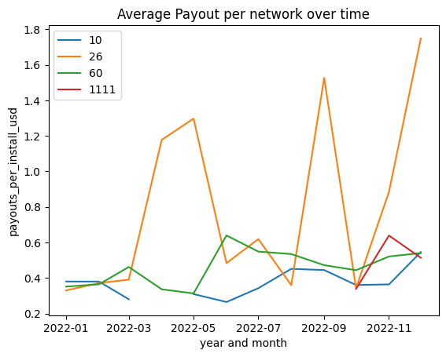

Active users are users that stayed active with the installation based on either payouts or revenue. The retention is then calculated as the number of active users divided by the total users.In addition, the number of days active is calculated as the difference between date of installation and the last day of activity.

The average retention rate for network 1111 is 92% although it has the lowest number of active days. This is because it does not have as mush data as the other networks. The average retention rate for network 10 and 60 is 86% these also have the highest revenue and the highest acquisition cost. Network 26 has \80% retention although according to the time series, the retention rate has been increasing over thr year.

```
   network_id  total_users  retained_users  retension_rate
0          10        26345           22755       86.373126
1          26        73979           60211       81.389313
2          60       110462           95469       86.427007
3        1111         6101            5665       92.853631
```

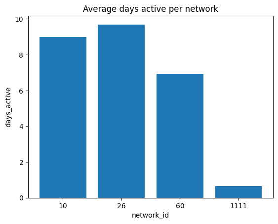

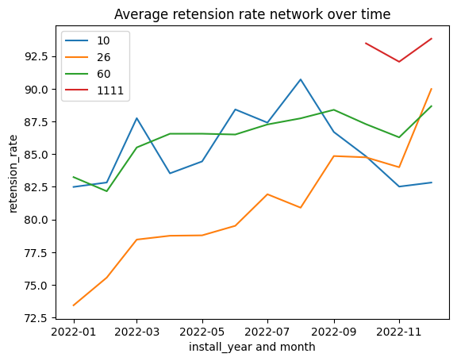

```
   network_id     profit_usd
0          10   32809.994177
1          26   87333.310038
2          60  192241.763548
3        1111    4675.889580
```

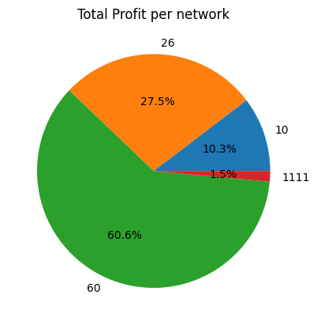

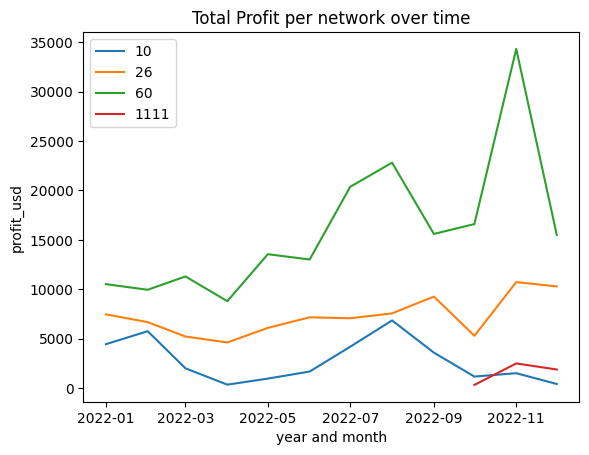

Based on the analysis of the KPIs, some networks perform better in terms of profit and retention despite having no acquisition cost. Therefore, in this section, we analyse the hypothesis that increasing acquisition cost will increase retention which will in turn increase profit. First, the correlation between acquisition costs and retention rates is 0.03. Using a linear regression between acquisition costs and retention rates, the trend line does not fit the data as shown in the scatter plot. This shows that acquisition cost has no effect on retention rate.

```
Correlation between acquisition costs and retention rates: 0.03021982327856542
```

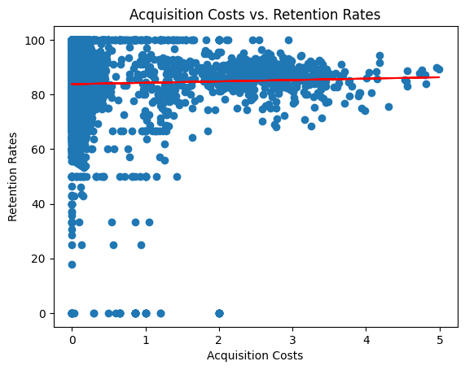

```
Correlation between retention rates and profits: 0.026885208892139075
```

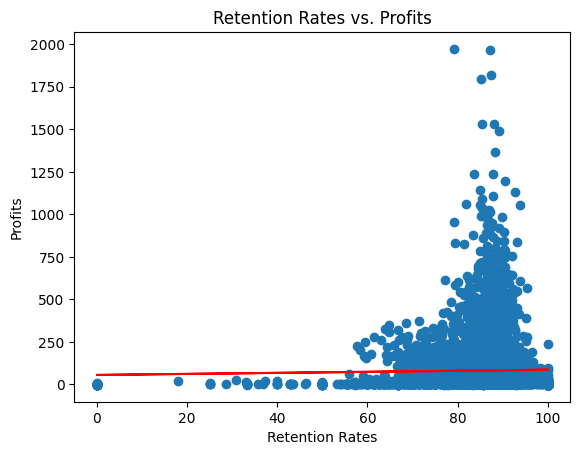

```
Perform hypothesis testing between acquisition costs and retention rates

Null hypothesis: increasing user acquisition costs do not lead to a higher user retention rate
Alternative hypothesis: increasing user acquisition costs lead to a higher user retention rate

Fail to reject the null hypothesis. There is no evidence that increasing user acquisition costs lead to a higher user retention rate.

Perform hypothesis testing between profit and retention rates

Null hypothesis: increasing user retention does not lead to a higher profits
Alternative hypothesis: increasing user retension lead to a higher profits

Fail to reject the null hypothesis. There is no evidence that increasing retension leads to a higher profits.
```

In addition to the analysis, further regression models or time series models can be run to give a general picture of the next financial year.